# Exploring what is in common with CRA and Alberta charity/nonprofit listing for Calgary

Paula Jennings

2022-06-28

## Read source files

Read and full join by Legal Entity Name of organization to keep information from all rows.

```r
may_non_profit_name_list_for_open_data_portal <- read_excel("may-non_profit_name_list_for_open_data_portal.xlsx")
head(may_non_profit_name_list_for_open_data_portal)
```

```
## # A tibble: 6 x 6
##   `Legal Entity T~` `Legal Entity ~` Status `Registration ~` City  `Postal Code`
##   <chr>             <chr>            <chr>  <chr>            <chr> <chr>
## 1 Agricultural Soc~ ACME & DISTRICT~ Active 1979/06/18       ACME  T0M0A0
## 2 Agricultural Soc~ AIRDRIE & DISTR~ Active 1974/09/11       AIRD~ T4B2V8
## 3 Agricultural Soc~ ALBERTA BEACH &~ Active 1975/01/27       ALBE~ T0E0H0
## 4 Agricultural Soc~ ALDER FLATS COM~ Active 1978/10/18       ALDE~ T0C0A0
## 5 Agricultural Soc~ ALIX AGRICULTUR~ Active 2008/06/11       ALIX  T0C0B0
## 6 Agricultural Soc~ ALLIANCE & DIST~ Active 1982/03/15       ALLI~ T0B0A0
```

```r
X2338_Calgary_Charities_CRA2020 <- read_csv("2338_Calgary_Charities_CRA2020.csv")
head(X2338_Calgary_Charities_CRA2020)
```

```
## # A tibble: 6 x 14
##   `Count of Account name` `Account name`          Description_E `BN/Registrati~`
##                     <dbl> <chr>                   <chr>         <chr>
## 1                       1 "\"POLANIE\" POLISH SO~ Charitable O~ 104256581RR0001
## 2                       1 "Abundant Life Church ~ Charitable O~ 814807624RR0001
## 3                       1 "ALBERTA SCIENCE NETWO~ Charitable O~ 129079315RR0001
## 4                       1 "AL-MADINAH CALGARY IS~ Charitable O~ 841674674RR0001
## 5                       1 "Altalma Foundation"    Charitable O~ 851124818RR0001
## 6                       1 "Bangladesh Puja Paris~ Private Foun~ 778190488RR0001
## # ... with 10 more variables: `Category English Desc` <chr>,
## #   `Sub-Category English Desc` <chr>, `Count of BN/Registration Number` <dbl>,
## #   Percent <dbl>, City <chr>, `Contact URL` <chr>, `Legal name` <chr>,
## #   `Mailing address` <chr>, `Postal code` <chr>, `Registration date` <dttm>
```

```r
dfabdata <- data.frame(distinct(may_non_profit_name_list_for_open_data_portal)) %>%
  filter(City == "CALGARY") %>%
  rename(Name = "Legal.Entity.Name") %>%
  mutate(source = "Alberta Open Data nonprofit Listing")
dfcradata <- data.frame(distinct(X2338_Calgary_Charities_CRA2020)) %>%
  mutate(Name = toupper(Legal.name)) %>%
  select(-City, -Account.name) %>%
  mutate(source = "CRA charity")

allnprecords <- full_join(dfabdata, dfcradata, by="Name")
```

## Focus on organizations in common to Alberta list and CRA originating list

Looking at number of organizations that intersect and are on both lists. The scope of this project was to consider Active organizations in Calgary defined by the Alberta government and then intersect with CRA T1030 Registered Charity Returns. Some of the organizations that appear in CRA data did not appear on the Active Alberta list. This gives how organizations intersect by Status.

```
##                         Status registered     n
## 1                       Struck         AB  5878
## 2                       Active         AB  4728
## 3                       Active        CRA  1418
## 4                         <NA>        CRA   859
## 5                    Dissolved         AB   838
## 6                        Start         AB   146
## 7                  Amalgamated         AB    74
## 8                       Struck        CRA    35
## 9                    Cancelled         AB    23
## 10                   Dissolved        CRA    11
## 11                       Start        CRA    11
## 12                     Con Out         AB     9
## 13                 Amalgamated        CRA     8
## 14                      Liquid         AB     8
## 15                   Cancelled        CRA     2
## 16                     Con Out        CRA     2
## 17           Temporary Restore         AB     2
## 18 Pending Revival/Restoration         AB     1
## 19                       Total      Total 14053
```

## Focus

The data with from the CRA is context rich and it seems reasonable to limit the categorization exercise with organizations that are active. We will have to find out why 859 organizations appear in the CRA dataset and work with the 1418 Active organizations that have filed returns with the CRA. If program information enriches our ability to apply keywords and tage to categories we can test how well that works on analyzing the organization names of the 4728 Active Alberta organizations that we have no program information for.

```r
allnprecords %>%
  rename(registered = Count.of.Account.name) %>%
  mutate(intersect_flag = replace_na(registered,0)) %>%
  mutate(registered = ifelse(intersect_flag == 0, "AB", "CRA")) %>%
  count(Status, registered, sort= T) %>%
  mutate(cases = replace_na(Status, "not found in AB list")) %>%
  filter(cases == "Active"| cases == "not found in AB list") %>%
  rename(count = n) %>%
  select(-Status) %>%
  bind_rows(summarize(., across(where(is.numeric), sum), across(where(is.character), ~"Total")))
```

```
##   registered count                cases
## 1         AB  4728               Active
## 2        CRA  1418               Active
## 3        CRA   859 not found in AB list
## 4      Total  7005                Total
```

## Subsetting to the focused data

The data we will concentrate on we will place in a dataframe and then try and figure out if there is a pattern between the description the Alberta listing notes for each organization and if they report to the CRA or not.

```r
nplist <- allnprecords %>%
  rename(registered = Count.of.Account.name) %>%
  mutate(intersect_flag = replace_na(registered,0)) %>%
  filter(Status == "Active")

nplist %>%
  mutate(Organization_type = replace_na(Description_E, "Not in CRA thereby not defined")) %>%
  group_by(Legal.Entity.Type.Description, Organization_type) %>%
  summarize(n = n()) %>%
  pivot_wider(names_from = Legal.Entity.Type.Description, values_from= n)
```

```
## # A tibble: 4 x 10
##   Organization_type           `Agricultural ~` `Alberta Socie~` `Extra-Provinc~`
##   <chr>                                  <int>            <int>            <int>
## 1 Charitable Organization                    1              753               61
## 2 Not in CRA thereby not def~                2             3100              263
## 3 Private Foundation                        NA               23               17
## 4 Public Foundation                         NA               44                4
## # ... with 6 more variables: `Non-Profit Private Company` <int>,
## #   `Non-Profit Public Company` <int>,
## #   `Private Act Non-Profit Corporation` <int>,
## #   `Recreation Private Company` <int>, `Recreation Public Company` <int>,
## #   `Religious Society` <int>
```

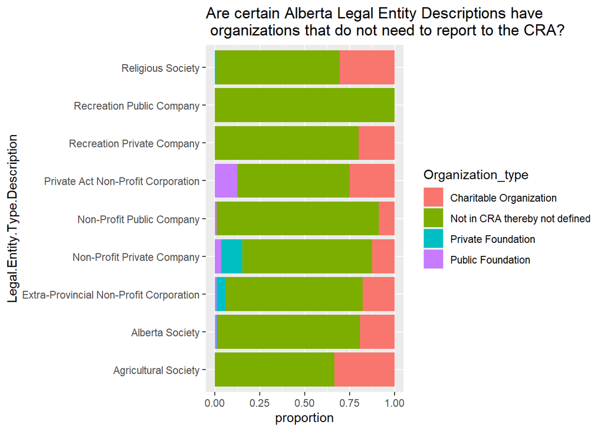

```r
nplist %>%
  mutate(Organization_type = replace_na(Description_E, "Not in CRA thereby not defined")) %>%
  group_by(Legal.Entity.Type.Description) %>%
  count(Organization_type) %>%
  mutate(proportion = n / sum(n)) %>%
  ggplot(aes(x=Legal.Entity.Type.Description, y=proportion, fill = Organization_type)) +
  geom_bar(stat = "identity") +
  ggtitle("Are certain Alberta Legal Entity Descriptions have\n organizations that do not need to report to the CRA?") +
  coord_flip()
```

## Description grouping and reporting to CRA is there a correlation? It appears that a proportion of every group except for the Alberta’s listing “Recreation Public Company” has a proportion of organizations that do report to the CRA and there is no real pattern. The Organization_type comes from the CRA and in a few cases there seems to be a contradiction where Public Foundation appears under Private Act Non-Profit Corporation and Non-Profit Private Company for example. Some definitions from the sources and knowing if the source of the description and if it is checked would be helpful in determining these that do not quite fit.

Since CRA reporting and non CRA reporting share the Alberta Description then we may have a chance in adding tags, adjectives and categorization based on the more comprehensive CRA data and then try and apply it to the Alberta organization names (which would be as good as how descriptive and accurate the name is).